# Michael Waldron CMSC320 final project: An analysis on the Universal Crime Report

## Introduction

To begin: what is the Universal Crime Report (UCR)? According to the Federal Bureau of Investigation, the UCR is “the starting place for law enforcement executives, students of criminal justice, researchers, members of the media, and the public at large seeking information on crime in the nation” (https://ucr.fbi.gov/?came_from=https%3A//ucr.fbi.gov/word/). More specifically, the UCR is a conglomerate of crime reports sent to the FBI by state/local police to track some of the most serious and frequent crimes on a national scale. What serious and frequent crimes are isn’t given a clear definition. To explain both with an example, take notice of how kidnapping is not included in the UCR. While kidnapping is certainly a serious crime, it is so rare that national scale statistical analyses wouldn’t be meaningful. The crimes included in the UCR are as follows (legal definitions given below): criminal homicide, rape, robbery, aggravated assault, burglary, larceny, and motor vehicle theft. The UCR provides data for these crimes by state and year, both in total and as a rate of instances per 100,000 citizens.

This tutorial will cover obtaining UCR data, tidying the data to make testing simpler, and some experiments that can be done with the data. On the individual/general level, crime analyses with the UCR can help to answer questions many of us have about crime. Is crime getting worse? Is my state safe? What crimes are more likely where I am? In terms of data science on the whole, analysis on the UCR can have implications on crime policy nation wide, effect political campaigns (to fact check candidates who focus on crime), and illustrate the importance of good data collection habits.

On that note, it is important to mention while the UCR is definitively the best resource for public crime reporting, the UCR is not perfect and any analyses done with its data need to be taken with a grain of salt. See the insights section for elaboration on this point.

### Document setup and loading libraries

```r
knitr::opts_chunk$set(cache=TRUE)
library(tidyverse)
library(fiftystater)
```

```r
library(evaluate)
library(mapproj)
library(magrittr)
library(ggpubr)
library(ISLR)
library(cvTools)
library(tree)
library(broom)
```

## Data curation, parsing, and management

UCR data can be viewed and downloaded as a .csv file from https://www.bjs.gov/ucrdata/Search/Crime/State/StatebyState.cfm?NoVariables=Y&CFID=161469185&CFTOKEN=32f049d01284740-856CB110-E22D-C0F7-1F3DA2D25C6191F1. This website provides a tool that allows users to choose what data they would like to select - in terms of state, crime, and/or year. The data used in this tutorial includes all states, crimes, and years so that we can filter the data on our own if necessary.

Before loading the UCR data into RStudio, open the .csv in a text editor and remove all the information after the last numerical entry. This will make parsing the document much easier in the next couple steps. However, the file’s formatting is still flawed, so the read.csv() function will not work. Instead, use the readLines() function and remove all lines that contain any alphabetic symbols. Once this is done we can read a textConnection of what is left and assign relevant names to all of the columns. Finally, I created a vector in excel to add a state column to our data frame. Each state has 55 entries (1 for each year from 1960 to 2014) except New York which is missing data for the first 5 years. Because our data includes the US total and District of Columbia, there will be 2855 total entries. After adding this column I chose to rearrange the table, so the state and year would be the first attributes.

```r
UCR_raw <- readLines("C:/Users/Michael/OneDrive/Current Semester/Intro to Data Science (CMSC320)/Projects/Final Project/CrimeStatebyState.csv")

UCR_grep <- grep("[:alpha:]", UCR_raw, invert=TRUE, value=TRUE)

UCR_df <- read.csv(textConnection(paste0(UCR_grep, collapse="\n")), header=FALSE, stringsAsFactors=FALSE)
names(UCR_df) <- c("year","population","violent_crime","homicide","legacy_rape","revised_rape","robbery","assault","property_crime","burglary","larceny","mvt","violent_crime_rate","homicide_rate","legacy_rape_rate","revised_rape_rate","robbery_rate","assault_rate","property_crime_rate","burglary_rate","larceny_rate","mvt_rate")

state_vector <- read.csv("C:/Users/Michael/OneDrive/Current Semester/Intro to Data Science (CMSC320)/Projects/Final Project/States Vector.csv")
UCR_df$state <- state_vector$state

UCR_df <- UCR_df[c("state","year","population","violent_crime","homicide","legacy_rape","revised_rape","robbery","assault","property_crime","burglary","larceny","mvt","violent_crime_rate","homicide_rate","legacy_rape_rate","revised_rape_rate","robbery_rate","assault_rate","property_crime_rate","burglary_rate","larceny_rate","mvt_rate")]

UCR_df %>%
  head(n=10)
```

```
##      state year population violent_crime homicide legacy_rape revised_rape
## 1  Alabama 1960    3266740          6097      406         281           NA
## 2  Alabama 1961    3302000          5564      427         252           NA
## 3  Alabama 1962    3358000          5283      316         218           NA
## 4  Alabama 1963    3347000          6115      340         192           NA
## 5  Alabama 1964    3407000          7260      316         397           NA
## 6  Alabama 1965    3462000          6916      395         367           NA
## 7  Alabama 1966    3517000          8098      384         341           NA
## 8  Alabama 1967    3540000          8448      415         371           NA
## 9  Alabama 1968    3566000          8288      421         396           NA
## 10 Alabama 1969    3531000          8842      485         494           NA
##    robbery assault property_crime burglary larceny  mvt violent_crime_rate
## 1      898    4512          33823    11626   19344 2853              186.6
## 2      630    4255          32541    11205   18801 2535              168.5
## 3      754    3995          35829    11722   21306 2801              157.3
```

[output cut: 29 more lines]

## Exploratory data analysis

First let’s illustrate the importance of distinguishing between crime and crime rates.

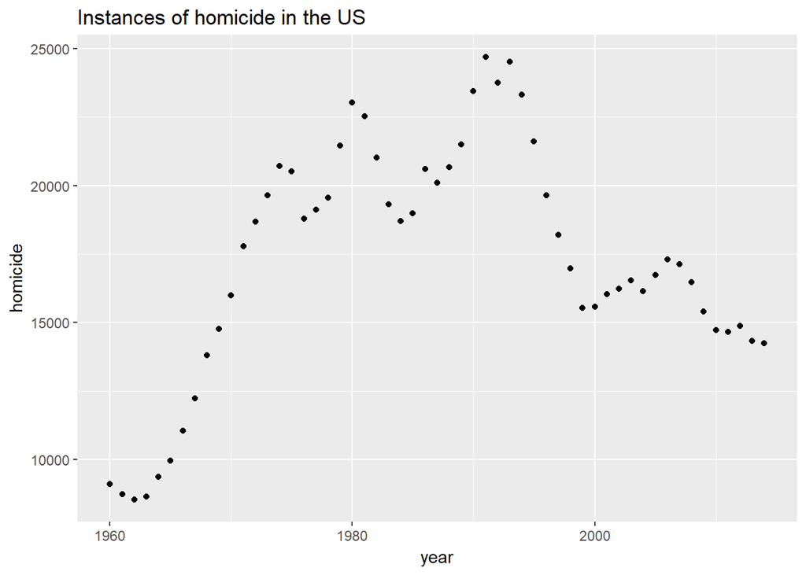

```r
UCR_df %>%
  filter(state == "US Total") %>%
  ggplot(aes(x=year, y=homicide)) +
  geom_point() +
  ggtitle("Instances of homicide in the US")
```

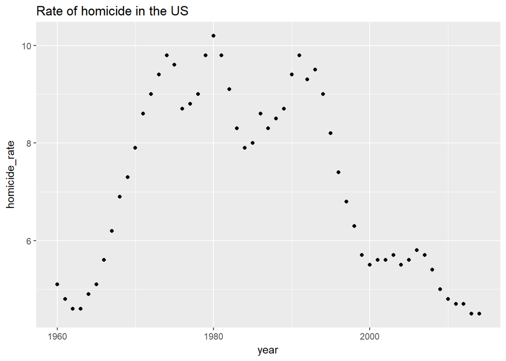

```r
UCR_df %>%
  filter(state == "US Total") %>%
  ggplot(aes(x=year, y=homicide_rate)) +
  geom_point() +
  ggtitle("Rate of homicide in the US")
```

Since we’ve discussed that great power comes with great responsibility, let’s see what we can do with our data.

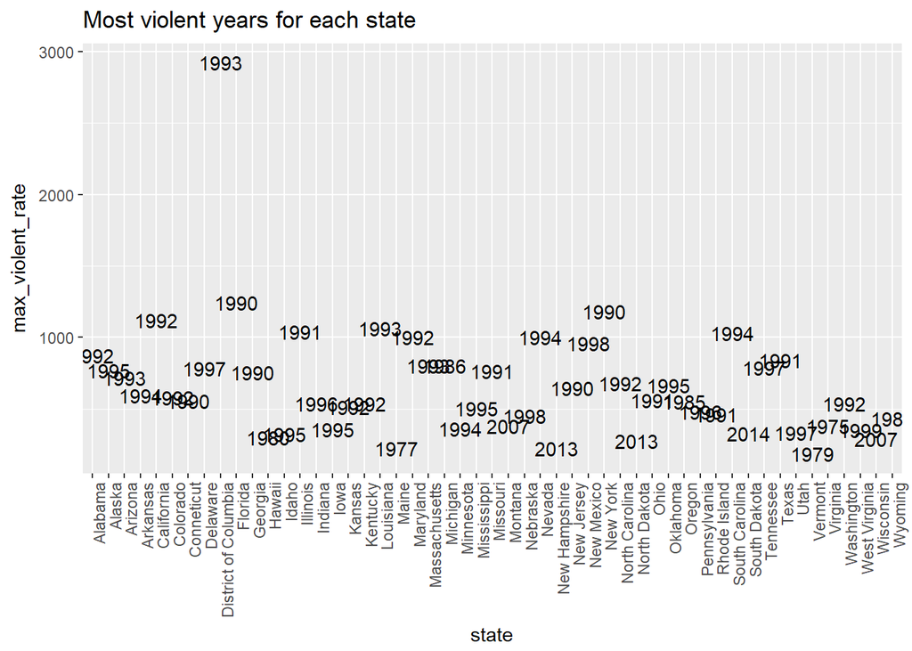

```r
violent_years <- UCR_df %>%
  filter(state != "US Total") %>%
  group_by(state) %>%
  mutate(max_violent_rate = max(violent_crime_rate)) %>%
  filter(violent_crime_rate == max_violent_rate)

violent_years %>%
  ggplot(aes(x=state, y=max_violent_rate)) +
  geom_text(aes(label=year)) +
  ggtitle("Most violent years for each state") +
  theme(axis.text.x = element_text(angle = 90, hjust = 1))
```

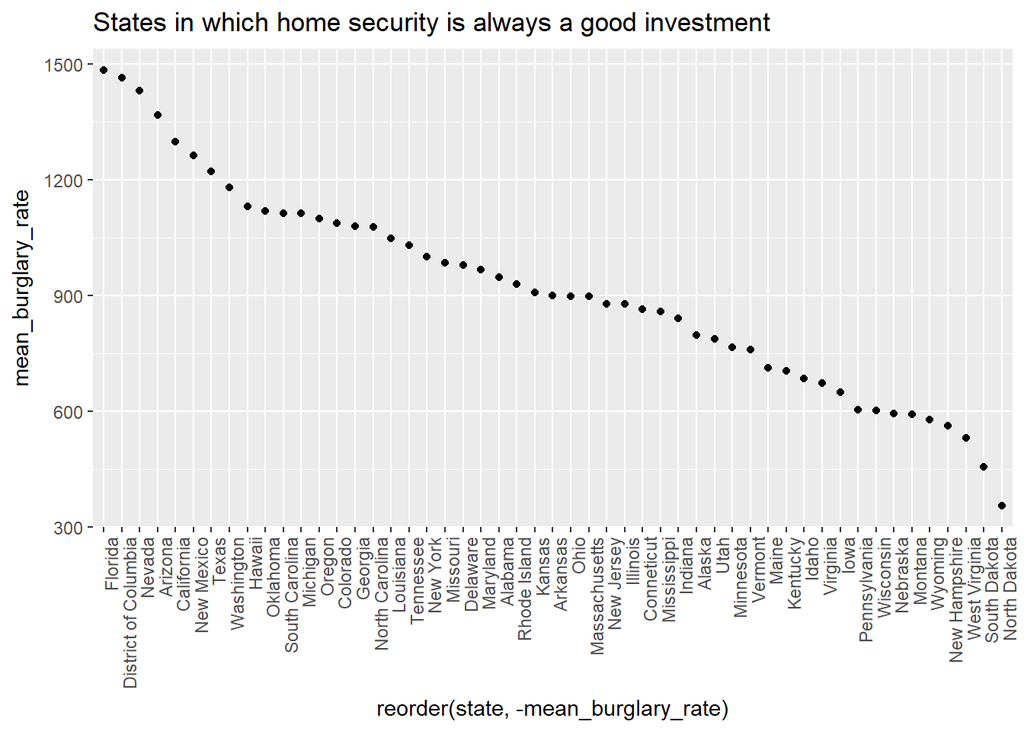

```r
UCR_df %>%
  filter(state!="US Total") %>%
  group_by(state) %>%
  summarize(mean_burglary_rate=mean(burglary_rate)) %>%
  ggplot(aes(x=reorder(state,-mean_burglary_rate), y=mean_burglary_rate)) +
  geom_point() +
  ggtitle("States in which home security is always a good investment") +
  theme(axis.text.x = element_text(angle = 90, hjust = 1))
```